# 決定木アルゴリズム: モデル集計

経済学のための機械学習入門

川田恵介

# モデル集計

- データ分析の基本的発想: 事例を集計することで、観察できない要因の偏りの影響を緩和
  - 予測モデルへの影響はどうしても残る
- 新しい発想: 予測モデル自体を”集計”する

## 比喩: 予測屋会議

- 複数の”専門家”の予測を集計して最終予測モデルとする
  - “エコノミスト”の見通しの平均値
  - 専門家委員会
- 一人の予測に頼るよりも、ましでは？
  - 教師付き学習にも応用可能な発想

## 数値例

- 独立して収集したデータについて、深い予測木 (剪定なし) を推定
- 各予測値と、予測値の平均を比較

## 予測結果

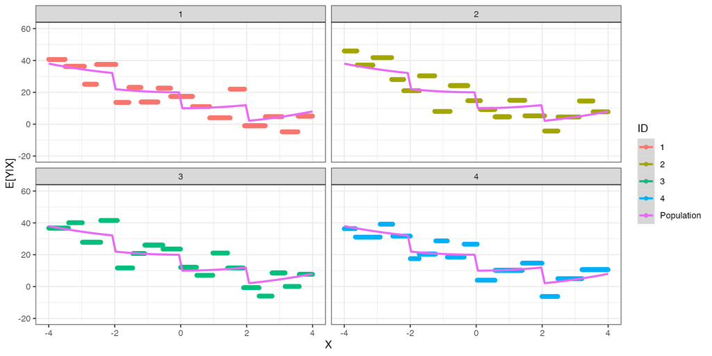

## 集計

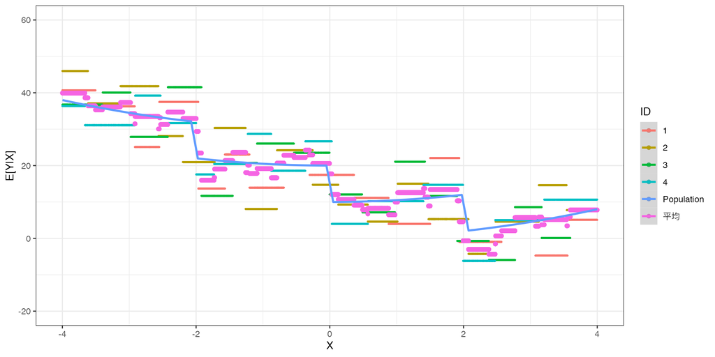

## チャレンジ

- 「独立して抽出された」有限個データから生成された予測モデル
- 「独立して抽出した複数のデータから得た」予測モデルの集計は通常不可能
  - 推定に使ったサンプルサイズが実質的に増えているので、性能改善は”当たり前”
- 近似的に行う
  - (Nonparametric) bootstrapの活用

# Bootstrap Aggregating

- Bagging

## 決定木の不安定性

- 現実は複雑なので、複雑なモデル(巨大な木)が本来は望ましい
  - 事例数が限られている場合、データ固有の特徴を強く反映してしまう
  - 適度に単純化する必要があるが、、、、
- 多くの実践で、決定木推定の不安定性( $=$ データ固有の特徴を強く反映してしまう)は、剪定を行っても十分に緩和できない
  - Bootstrapでデータを複製して、モデル集計

## 理想のBagging

```
flowchart TB
  A[Prediction Task] --> B{Random Sampling}
  B --> C[Data 1]
  B --> D[Data 2]
  B --> E[Data 3]
  C --> F[Tree 1]
  D --> G[Tree 2]
  E --> H[Tree 3]
  F --> J[Aggregate]
  G --> J
  H --> J
```

## アルゴリズム

1. Nonparametric bootstrapで、データの複製を行う (500,1000,2000など)
2. 各複製データについて、“深い”決定木を推定
3. 各 $X$ についての予測値の平均を最終予測値とする

## 補論: Bootstrap

```
flowchart TB
  B{Original Data ID 1,2,3} --> C[ID 1,2,2]
  B --> D[ID 2,3,1]
  B --> E[ID 3,3,2]
  C --> F[Tree 1]
  D --> G[Tree 2]
  E --> H[Tree 3]
  F --> J[Aggregate]
  G --> J
  H --> J
```

## Baggingの発想

- 基本アイディア: 非常に深い木を生成すれば、予測結果が不安定になるが、
- 平均を取れば、安定する
  - 独立・無相関であれば、 無限個の**複製データ**から予測モデルを作れば、分散を0にできる
  - 今のPCであれば、大量の予測モデルの生成は可能

## Baggingの限界

- リーマンショック、地震保険が(火災保険などと比べて)難しい理由は？
  - 事象間での相関
- よく似た予測結果ばかりであれば、平均をとってもあまり意味がない
  - 予測結果を十分に”散らばらせる”必要がある
  - 金融ポートフォリオであれば、平均的なリターンが低く買ったとしても、”海外”の商品も組み込むなど

## RandomForest

- データ分割に用いることができる変数群をランダムに選ぶ
- 例：ある予測木の第n分割を行う際に
  - Bagging: $\{$ 年齢、性別、学歴 $\}$ から選ぶ
  - Random Forest: $\{$ 年齢、性別 $\}$ から選ぶ
    - 第 $n+1$ 分割を行う際には、 $\{$ 学歴、性別 $\}$

## RandomForest: 動機

- 動機: 予測値同士の相関を弱める
  - 相関を強める要因(データが多少変わっても、同じような変数を活用する)を排除
  - そこそこの予測力を持つ変数が、強力な予測力を持つ変数の陰に隠れてしまうことを避けられる

## 数値例

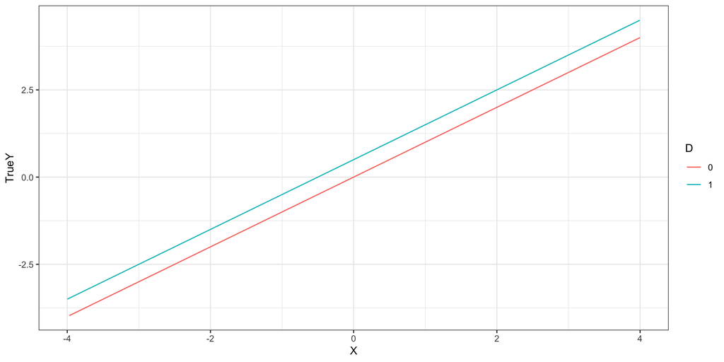

## 数値例

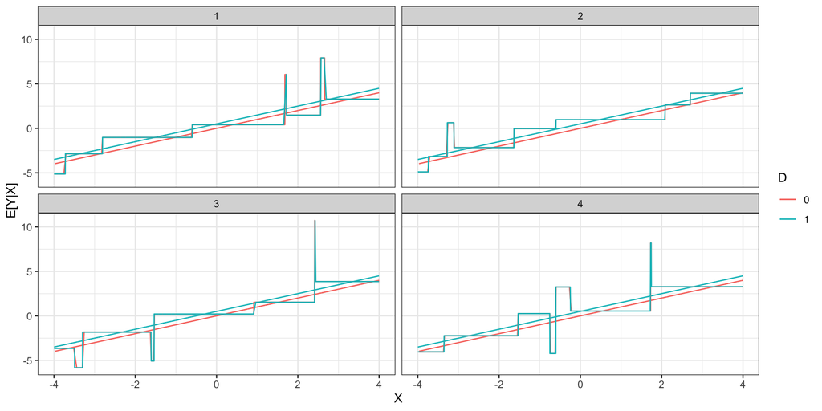

## 数値例

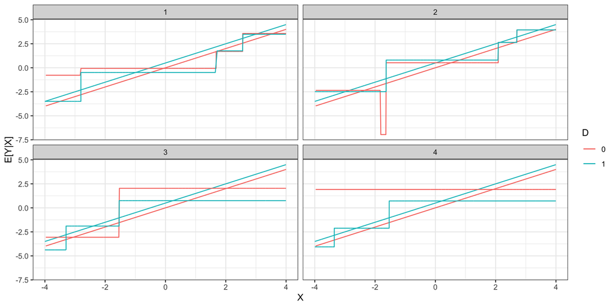

## 実例

```r
X <- select(Data, -Price)

Y <- Data$Price

Fit <- SuperLearner(
  X = X,
  Y = Y,
  SL.library = c(
    "SL.mean",
    "SL.rpart",
    "SL.rpartPrune",
    "SL.ranger"
  )
  )

Fit$cvRisk
```

```
      SL.mean_All      SL.rpart_All SL.rpartPrune_All     SL.ranger_All
         696.8034          307.2621          269.4826          218.9182
```

# まとめ

- Resampling $=$ 元々のデータから、“新しい”データを作り出す
- Resamplingは現代のデータ分析において、強力な手法
  - 交差検証(事例の被りは許さない): モデル評価など
  - Bootstrap: モデルの改善(Bagging/RandomForest)
  - 伝統的なInferenceへのBootstrapの応用も、もちろん重要